# Data Wrangling in tidyr

Javier Patron

2022-08-15

## Read in the world bank data files

```r
wb_indicators <- read_csv(here::here("data", "wb_indicators.csv"), na = c("..", ""))
world_metadata <- read_csv(here::here("data", "wb_indicators_metadata.csv"))
```

### Tidy up the data

```r
wb_indicators_long <- wb_indicators |>
  pivot_longer(cols = "2001 [YR2001]": "2020 [YR2020]",
               names_to = "years",
               values_to = "indicator_value")
```

## Separate to clean up the year column

```r
wb_clean <- wb_indicators_long |>
  separate(col = years, into = c("year", "year_chr"), sep = " ") |>
  select(-year_chr, -"Country Code", -"Series Code") |>
  mutate(year = as.numeric(year))|>
  drop_na("Series Name") |>
  pivot_wider(names_from = "Series Name", values_from = indicator_value)
```

### Rename the titles for each column

```r
names(wb_clean) <- c("country", "year", "access_clean_fuels_pp", "access_electricity_pp", "co2_emissions_kt", "fossil_fuel_cons_pct", "water_specs")
```

##Subset for specific countries

```r
wb_subset <- wb_clean |>
  filter(country %in% c("Algeria", "Barbados","Bulgaria", "Chile"))
```

## Lets Graph!

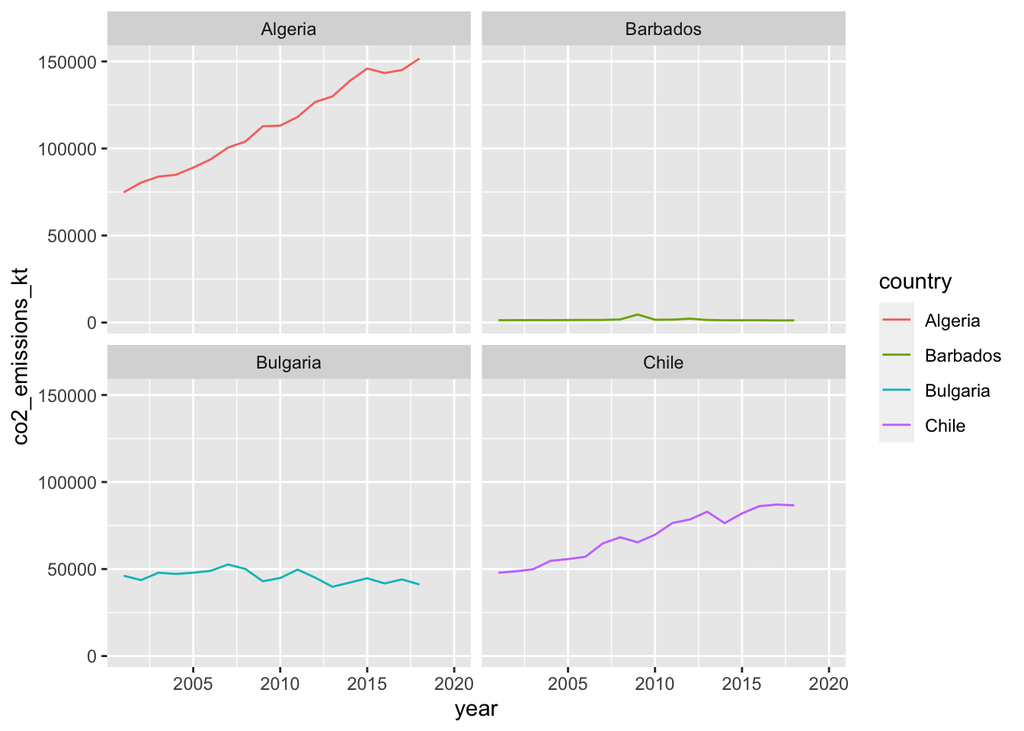

```r
ggplot(data = wb_subset, aes(x = year, y = co2_emissions_kt)) +
  geom_line(aes(color = country)) +
  facet_wrap(~country)
```

```r
ex_1 <- starwars |>
  filter(height > 180)
```

### Get the exact number match

```r
ex_2 <- starwars |>
  filter(eye_color == "blue")
```

### Example 3: Make a subset of starwars for only NABU as the home world

```r
ex_3 <- starwars |>
  subset(homeworld == "Naboo")
```

### Double conditions in a data frame

```r
ex_4 <- starwars |>
  filter(height > 180 & homeworld == "Tatooine")
```

### Example5: Create a subset where the hair color is brown and the species is human

```r
ex_5 <- starwars |>
  filter(hair_color == "brown" & species == "Human")
```

### Example 6: Filtering OR statements

```r
ex_6 <- starwars |>
  filter(height > 180 | eye_color == "yellow")
```

### Example 7: Create a subset that keep rows if homeworld is Endor OR species is droid

```r
ex_7 <- starwars |>
  filter(homeworld == "Endor" | species == "droid")
```

### Example 8: Eye color (blue,brown,red)

```r
ex_8 <- starwars |>
  filter(eye_color == "blue" | eye_color == "red" | eye_color == "brown")


ex_9 <- starwars |>
  filter(eye_color %in% c("brown", "red", "blue"))


# YOU DONT WANT TO DO THIS

ex_10 <- starwars |>
  filter(eye_color == c("brown", "red", "blue"))
```

### Example 11. Create a subset where homewoeld is endor or Tattoine or naboo and height < 150

```r
ex_11 <- starwars |>
  filter(height < 150, homeworld %in% c("Endor", "Tatooine", "Naboo"))

ex_12 <- starwars |>
  filter(species != "Human" )
```

### Use the subset

```r
ex_13 <- subset(starwars, species == "Human", select = c(name, sex, gender,species))
```

## Use `select`: select or exclude columns

```r
# Select by name

ex_14 <- wb_clean |>
  select(country,year, co2_emissions_kt)

ex_15 <- wb_clean |>
  subset(select = c(country, year, co2_emissions_kt))
```

Multiple pipes together

```r
ex_17 <- wb_clean |>
  filter(country %in% c("Bolivia", "Chile", "Mexico")) |>
  select(country:fossil_fuel_cons_pct)

ex_18 <- subset(wb_clean, country %in% c("Bolivia", "Chile", "Mexico"), select = country:fossil_fuel_cons_pct)
```

Example 19- SELECT ONLY COLUMNS FOR COUNTRY, YEAR, AND WATER STRESS AND REORDER THEM AS YEAR, COUNTRY WATER STRESS, THEN FILTER TO ONLY INCLUDE OBSERVATIONS FOR ANY THREE COUNTRIES OF YOUR CHOOSING

```r
ex_19 <- wb_clean |>
  select(country, year, water_specs) |>
  filter(country %in% c("Fiji"))
```

### Change the names of the columns `rename`

```r
ex_20 <- wb_clean |>
  rename(ffcp = fossil_fuel_cons_pct, ws = water_specs)
```

`mutate`: update an existing column, or add a new one If you assign a NEW column name, it will add a new column to the end of your data frame. If you assign an existing column name, it will overwrite that column

```r
ex_22 <- wb_clean |>
  mutate(co2_emissions_t = co2_emissions_kt * 1000)

ex_23 <- wb_clean |>
  mutate(co2_emissions_t = co2_emissions_kt * 1000) |>
           relocate(co2_emissions_t, .after = co2_emissions_kt)

ex_24 <- wb_clean |>
  mutate(year = as.character(year))

ex_25 <- wb_clean |>
  mutate(year = as.numeric (year))
```

### dplyr relocate the columns

```r
ex_26 <- wb_clean |>
  relocate(water_specs, .after = year)
```

### Use of group_by

group_by: Creates groups under the hood . Doesnt chance anything superficial. Under the hood os where summarize comes in summarize: apply youir functions to EACH GRPUP, and return them in a nice summary table

```r
# Calculate the average height by species

ex_27 <- starwars |>
  filter(homeworld %in% c("Naboo")) |>
  group_by(species) |>
  summarize(mean_height = mean(height, ra.rm = TRUE),
            mean_mass = mean(mass, ra.rm = TRUE))

ex_28 <- starwars |>
  group_by(species) |>
  summarise(mean_height = mean(height, ra.rm = TRUE),
            mean_mass = mean(mass, ra.rm = TRUE))
```

```r
df <- tribble(
  ~species, ~length, ~number,
  "lobster", 12, 4,
  "lobster", 14, 6,
  "lobster", 15, 2,
)

df_case <- df |>
  uncount(number)
```

### count function for observations

# combination of group_by summarize n()

```r
starwars |>
  count(homeworld, species)
```

```
## # A tibble: 58 × 3
##    homeworld      species       n
##    <chr>          <chr>     <int>
##  1 Alderaan       Human         3
##  2 Aleen Minor    Aleena        1
##  3 Bespin         Human         1
##  4 Bestine IV     Human         1
##  5 Cato Neimoidia Neimodian     1
##  6 Cerea          Cerean        1
##  7 Champala       Chagrian      1
##  8 Chandrila      Human         1
##  9 Concord Dawn   Human         1
## 10 Corellia       Human         2
## # … with 48 more rows
## # ℹ Use `print(n = ...)` to see more rows
```

```r
starwars |>
  group_by(homeworld,species) |>
  summarize(size = n(),
            mean_height = mean(height, na.rm= TRUE))
```

```
## # A tibble: 58 × 4
## # Groups:   homeworld [49]
##    homeworld      species    size mean_height
##    <chr>          <chr>     <int>       <dbl>
##  1 Alderaan       Human         3        176.
##  2 Aleen Minor    Aleena        1         79
##  3 Bespin         Human         1        175
##  4 Bestine IV     Human         1        180
##  5 Cato Neimoidia Neimodian     1        191
##  6 Cerea          Cerean        1        198
##  7 Champala       Chagrian      1        196
##  8 Chandrila      Human         1        150
##  9 Concord Dawn   Human         1        183
## 10 Corellia       Human         2        175
## # … with 48 more rows
## # ℹ Use `print(n = ...)` to see more rows
```

Practice example: - Start from wb_clean - Only keep observations for Nicaragua, Ecuador, peru and Chile, AND for years greater than 2005 - Only co2 emissions - find the toal co2 emissions converted to megatons

```r
ex_29 <- wb_clean |>
  filter(country %in% c("Nicaragua", "Ecuador", "Peru", "Chile") & year > 2005) |>
  select(country, year, co2_emissions_kt) |>
  mutate(co2_emissions_kt, co2_emissions_MT = co2_emissions_kt/1000) |>
  group_by(country) |>
  summarize(total_co2_mt = sum(co2_emissions_MT, na.rm = TRUE))
```